# UNIT 1

# **📌 Unit-I: Introduction to Software and Software Engineering**

## **1️⃣ What is Software?**

Software is a **set of instructions** that tells a computer what to do. 🖥️  
It is a **collection of programs** that perform various operations, from simple calculations to complex problem-solving.

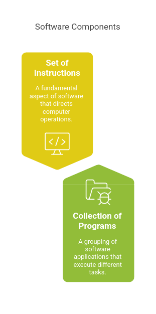

### **🔍 Key Features of Software**

✅ It is **intangible** (exists in digital form).  
✅ It is a **logical entity**, not physical hardware.  
✅ Helps users **interact with computers** and perform various tasks.

### **🔹 Real-Life Example:**

Imagine you are a **graphic designer** 🎨 and want to create a logo. You install **Adobe Photoshop** (software) on your computer. Without Photoshop, you can’t edit images effectively, even though your computer hardware (monitor, CPU, keyboard) is working fine.

## **🔍 Types of Software**

Software is categorized into **two main types**:  
1️⃣ **System Software** 🏗️ (Manages hardware and system operations).  
2️⃣ **Application Software** 📱 (Performs user-specific tasks).

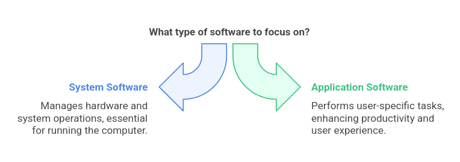

# **🖥️ System Software**

System software is designed to **manage and control hardware components**.  
It also **acts as a bridge** between hardware and user applications.

### **📌 Key Characteristics of System Software:**

✅ Works **closely with hardware** ⚙️  
✅ Written in **low-level programming languages** 🏗️  
✅ **Fast execution speed** 🚀  
✅ Less interactive for users **(works in the background)** 🔄

## **⚙️ Types of System Software**

### **1️⃣ Operating System (OS) 🏢**

The OS is the **first software** that loads when a computer starts. It:

- Manages **memory, CPU, input/output devices**, and files.
- Provides a **user interface** (UI) to interact with the system.

**📌 Examples:**  
✅ **Windows 11** 🖥️  
✅ **macOS Ventura** 🍏  
✅ **Linux Ubuntu** 🐧

### **🔹 Real-Life Scenario:**

You turn on your **laptop**, and the Windows logo appears. The OS manages how applications open, multitask, and access the internet. Without it, your laptop is just a **blank screen** 📟.

### **2️⃣ Language Processor 🛠️**

Computers **do not understand human languages**. Language processors **convert human-readable code** into **machine language (binary - 0s and 1s).**

**📌 Types of Language Processors:**  
✅ **Compiler**: Converts the entire program **at once**.  
✅ **Interpreter**: Converts code **line by line** while executing it.  
✅ **Assembler**: Converts assembly language into machine code.

**🔹 Real-Life Scenario:**  
A software engineer writes a **Python program** 🐍 to automate attendance. The **interpreter** translates and runs it **line by line**, ensuring correct execution.

### **3️⃣ Device Driver 🎛️**

- A program that **controls external devices** like printers, scanners, and keyboards.
- Without device drivers, the OS **cannot communicate** with hardware.

**📌 Examples:**  
✅ **Printer Driver** 🖨️  
✅ **Sound Card Driver** 🎵  
✅ **Graphic Card Driver** 🎮

**🔹 Real-Life Scenario:**  
You buy a new **wireless gaming mouse** 🖱️. When you plug it into your laptop, Windows **automatically installs the driver** so the mouse works properly.

# **📱 Application Software**

Application software is designed to **perform specific user tasks** beyond basic system operations.

### **📌 Features of Application Software:**

✅ Performs **specialized tasks** 📝  
✅ Written in **high-level programming languages** (Python, Java, C++)  
✅ **User-friendly & interactive** 🎨  
✅ Larger in size, requiring **more storage space** 💾

## **📂 Types of Application Software**

### **1️⃣ General Purpose Software 🏆**

- Used for multiple tasks, **not limited to one function**.
- **Examples:**  
  ✅ **Microsoft Office Suite** 📝  
  ✅ **Web Browsers (Google Chrome, Firefox)** 🌍  
  ✅ **VLC Media Player** 🎬

**🔹 Real-Life Scenario:**  
A student uses **MS Excel** to track **monthly expenses**, create **charts**, and calculate totals using formulas. Without Excel, doing this manually would take much longer!

### **2️⃣ Customized Software 🏦**

- Developed for **specific businesses or industries**.
- Tailored to meet **particular needs**.
- **Examples:**  
  ✅ **Banking Software** 🏦  
  ✅ **Hospital Management System** 🏥  
  ✅ **Airline Ticketing System** ✈️

**🔹 Real-Life Scenario:**  
A hospital installs **specialized medical billing software** to handle patient records, appointments, and payments. This software is **custom-built** only for hospitals.

### **3️⃣ Utility Software 🛡️**

- Supports **system maintenance** and **performance optimization**.
- **Examples:**  
  ✅ **Antivirus Software** 🦠  
  ✅ **Disk Cleanup** 🧹  
  ✅ **Backup Software** 💾

**🔹 Real-Life Scenario:**  
Your computer becomes **slow and laggy**. Running **Disk Cleanup** removes **junk files**, making it **faster**! 🚀

# **🔄 Difference Between System & Application Software**

| Feature | System Software 🏗️ | Application Software 📱 |
| --- | --- | --- |
| **Purpose** | Manages system resources | Performs user-specific tasks |
| **User Interaction** | Less interactive | Highly interactive |
| **Language Used** | Low-level (C, Assembly) | High-level (Java, Python) |
| **Examples** | Windows OS, Linux | MS Word, Photoshop |

**🔹 Real-Life Scenario:**  
Your laptop has **Windows OS (System Software)** to **run** MS Word (Application Software) where you can type documents. Without **Windows**, MS Word won’t work!

# **🔍 Software Engineering as a Layered Technology**

Software engineering follows a **layered approach** to ensure that software is **high-quality, maintainable, and efficiently developed**. Each layer depends on the one below it, forming a **structured framework** for software development.

## **⚡ 4 Layers of Software Engineering:**

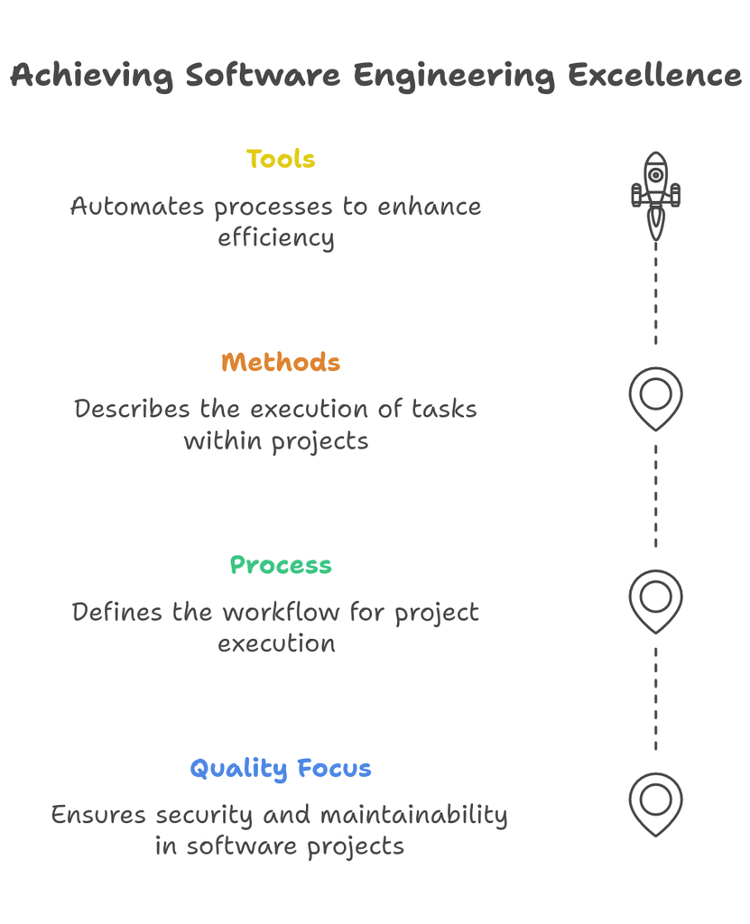

### **1️⃣ Quality Focus 🔐 (Ensures Security, Maintainability, and Reliability)**

- Ensures **error-free, secure, and scalable** software.
- Focuses on **data integrity, system usability, and long-term maintenance**.
- Involves **testing, debugging, performance optimization, and security measures**.

**🔹 Real-Life Scenario:**  
A **banking app** 🏦 must ensure that customer data is encrypted and protected from hackers. Without strong security, **cybercriminals could steal financial information**, leading to **fraud and financial loss**.

### **2️⃣ Process 🔄 (Defines Workflow and Project Execution)**

- Forms the **foundation of software engineering**, ensuring projects stay **on time and within budget**.
- Covers **requirement gathering, planning, designing, coding, testing, and maintenance**.
- Ensures **team collaboration, resource allocation, and risk management**.

**🔹 Real-Life Scenario:**  
A **fitness tracking app** 🏋️ follows a structured process. Developers **first gather user requirements**, then **plan, design, develop, test, and launch** the app to ensure smooth functionality.

### **3️⃣ Methods 🛠️ (Defines How Tasks Are Performed)**

- Provides **techniques and guidelines** for software development.
- Covers activities like **requirement analysis, system design, coding standards, and testing strategies**.
- Helps in **reducing errors and improving efficiency**.

**🔹 Real-Life Scenario:**  
A **self-driving car software** 🚗 follows strict **coding and testing methods** to prevent failures. Engineers test the AI system in **controlled environments before public release** to avoid accidents.

### **4️⃣ Tools 🔧 (Automation for Efficiency & Accuracy)**

- Software tools **automate repetitive tasks** like coding, debugging, testing, and version control.
- Examples:  
  ✅ **GitHub** – Version control.  
  ✅ **JIRA** – Project management.  
  ✅ **Selenium** – Automated testing.

**🔹 Real-Life Scenario:**  
A **tech startup** 🏢 uses **JIRA** to assign tasks, **GitHub** to manage code versions, and **Selenium** to automate testing, reducing manual effort and improving productivity.

## **⚙️ Software Process Framework (5 Key Activities) 🏗️**

1️⃣ **Communication 📢** – Understanding client needs and gathering requirements.  
2️⃣ **Planning 🗓️** – Setting development timelines, defining project scope, and resource allocation.  
3️⃣ **Modeling 🏛️** – Creating software blueprints, UI/UX design, and system architecture.  
4️⃣ **Construction 💻** – Writing code, integrating features, and conducting unit testing.  
5️⃣ **Deployment 🚀** – Delivering the software, gathering user feedback, and refining it further.

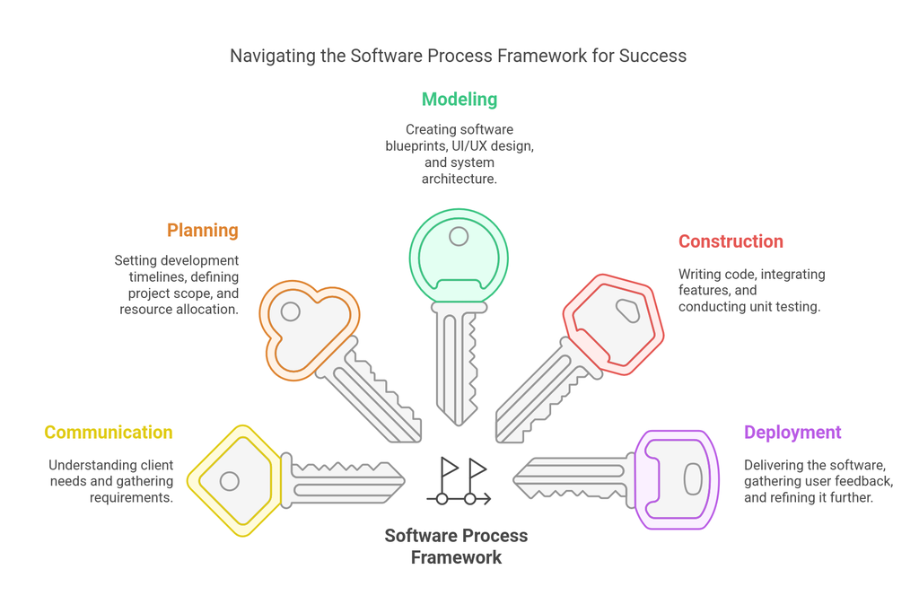

**🔹 Real-Life Scenario:**  
A **food delivery app** 🛵 follows these steps:  
1️⃣ **Communicates** with restaurant partners for requirements.  
2️⃣ **Plans** the development cycle and assigns tasks.  
3️⃣ **Models** the user interface.  
4️⃣ **Constructs** and tests the app.  
5️⃣ **Deploys** it for users and collects feedback for improvements.

## **🔍 Umbrella Activities (Supporting Processes)**

✅ **Software Project Tracking 📊** – Monitoring project progress to stay on schedule.  
✅ **Risk Management ⚠️** – Identifying and mitigating potential failures or security threats.  
✅ **Software Quality Assurance ✔️** – Conducting reviews and testing to ensure bug-free software.  
✅ **Configuration Management 🗄️** – Managing software updates, patches, and version control.  
✅ **Measurement & Optimization 📏** – Collecting data to improve software performance and efficiency.

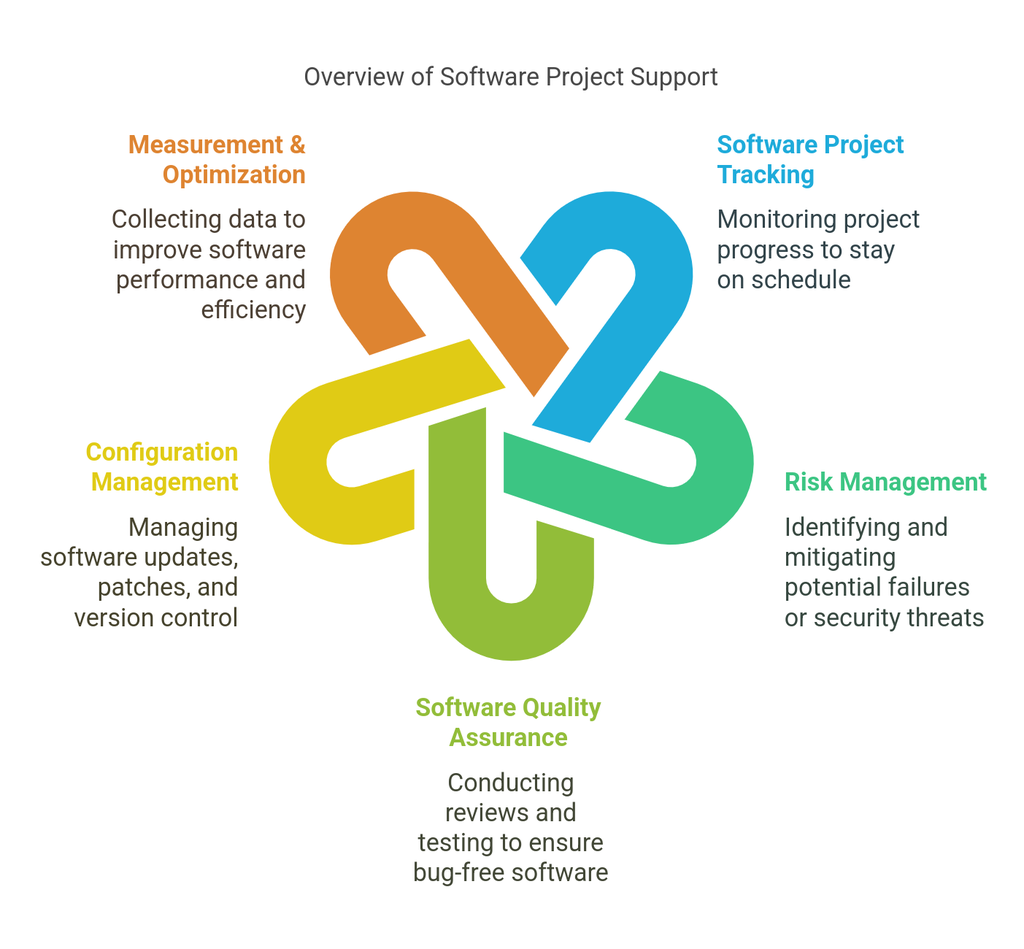

**🔹 Real-Life Scenario:**  
Before launching a **new video game** 🎮, developers **track progress**, test for **bugs and performance issues**, manage **updates**, and optimize **game speed** before the final release.

### **🔹 Why is This Approach Important?**

✔️ Ensures **high-quality and error-free software**.  
✔️ Provides **structured development and efficient teamwork**.  
✔️ Helps **reduce risks, improve security, and enhance user experience**.